# GLM и биномиальная регрессия

A. Angelgardt

# Краткое summary, что мы уже знаем

1. Знаем базовый R и умеем работать в пакете [tidyverse](https://www.tidyverse.org/)
2. Умеем тестировать статистические гипотезы и проверять значимость рассчитанных статистик
3. Умеем подбирать модель простой и множественной линейной регрессии и тестировать ее качество
4. Шарим в дисперсионном анализе и понимаем, что это та же саммая регрессия, только без количественного предиктора.

# Ограничения общих линейных моделей

Модели, которые мы изучали на предыдущих занятиях носят название **общих линейных моделей (general linear models)**. Они достаточно просты и удобны в большинстве случаев, однако имеют ряд важных ограничений.

Вспомним, как выглядит уравнение такой модели:
$$y = \beta_0 + \beta_1 x_1 + \dots + \beta_p x_p + \varepsilon$$

Предикторы в такой модели могут быть как дискретными, так и непрерывными.

Важнейшим допущением / требованием этой модели является распределение ошибки:
$$\varepsilon \thicksim \mathcal{N}(0, \, \sigma)$$

Поскольку ошибка модели должна быть распределена нормально, а моделируется среднее значение, то можно сформулировать более общее допущение / требование:
$$y_i \thicksim \mathcal{N}(\mu_i, \, \sigma)$$

Таким образом, общие линейные модели позволяют моделировать зависимости только для нормально-распределенных величин. Если же отклик модели (он же зависимая переменная) подчиняется другому распределению, эти модели не годятся.

Однако нам на помощь приходят **обобщенные линейные модели (generalized linear models)**, которые позволяют моделировать зависимости величин, подчиняющихся не только нормальному распределению, но и многим другим.

Мы познакомимся с общей логикой построения GLM, подробно рассмотрев один из вариантов таких моделей, а именно **биномиальную регрессию**.

# Биномиальное распределение

[Биномальное распределение](https://ru.wikipedia.org/wiki/Биномиальное_распределение) описывает вероятность выпадения определенного числа «успехов» в серии [испытаний Бернулли](https://ru.wikipedia.org/wiki/Схема_Бернулли).

Здесь можно [поиграться](https://angelgardt.shinyapps.io/binomial_app).

# Бинарные переменные

Эти переменные достаточно широко распространены как повседневности, так и в науке. Блюдо вкусное или невкусное, команда выиграла или проиграла, пациент в результате медицинских манипуляций выжил или умер, в ходе эксперимента была выбрана какая-то опция или нет, сдал студент экзамен или не сдал — и т.д.

Эти события могут быть связаны с раздичными предикторами, и такую взаимосвязь можно описать с помощью регрессионных моделей.

# Морские звезды и мидии

> Данные Khaitov et al., 2018

[Тут](https://raw.githubusercontent.com/angelgardt/hseuxlab-andan/master/aster_mussel.csv) есть датасет про мидий. Это экспериментальные данные, которые были собраны, чтобы понять, различают ли морские звезды два вида мидий.

Ценные промысловые моллюски, атлантические мидии, обитают в Белом море, но недавно туда вселились мидии другого вида — тихоокеанские. Вселенцы имеют меньшую промысловую значимость, и важно понять, что регулирует их численность. Наиболее значимый фактор — морские звезды, которые ими питаются.

Грузим данные.

```r
library(tidyverse)
library(car)
theme_set(theme_bw())
```

```r
mussels <- read_csv('https://raw.githubusercontent.com/angelgardt/hseuxlab-andan/master/aster_mussel.csv')
```

Смотрим их структуру.

```r
str(mussels)
```

```
## Classes 'spec_tbl_df', 'tbl_df', 'tbl' and 'data.frame': 286 obs. of  4 variables:
##  $ Box    : num  1 1 1 1 1 1 1 1 1 1 ...
##  $ L      : num  33.1 24.8 33 18.8 34 22.6 34.5 17.8 29.9 21.4 ...
##  $ Sp     : chr  "Tr" "Ed" "Ed" "Ed" ...
##  $ Outcome: chr  "not_eaten" "not_eaten" "not_eaten" "not_eaten" ...
##  - attr(*, "spec")=
##   .. cols(
##   ..   Box = col_double(),
##   ..   L = col_double(),
##   ..   Sp = col_character(),
##   ..   Outcome = col_character()
##   .. )
```

У нас есть следуюшие переменные:

- `Outcome` — съели мидию или нет
- `Sp` — вид мидий (`Ed` — корреной вид, `Tr` — вселенец)
- `L` — длина мидий (мм)
- `Box` — номер контейнера, в котором прододился эксперимент

Поизучаем и подправим данные.

```r
colSums(is.na(mussels))
```

```
##     Box       L      Sp Outcome
##       0       0       0       0
```

```r
table(mussels$Box)
```

```
##
##  1  2  3  4
## 66 68 74 78
```

Подправим данные. Сделаем факторными переменные, которые должны быть таковыми, и перекодируем `Outcome`.

```r
mussels %>% mutate(Box = as_factor(Box),
                   Sp = as_factor(Sp),
                   Out = ifelse(mussels$Outcome == 'eaten', 1, 0)) -> mussels
```

Перекодирование нужно для того, чтобы алгоритм подборки модели корректно отработал.

# Задача построения линейной модели

Чтобы ответить на вопрос, различают ли звезды разные виды мидий, нам нужно построить модель, описывающую связь `Outcome` (=`Out`) с предикторами `Sp` и `L`.

Попробуем обычную линейную регрессию.

```r
fit0 <- lm(Out ~ Sp * L, mussels)
summary(fit0)
```

```
##
## Call:
## lm(formula = Out ~ Sp * L, data = mussels)
##
## Residuals:
##      Min       1Q   Median       3Q      Max
## -0.41803 -0.11835 -0.08124 -0.04458  0.96140
##
## Coefficients:
##              Estimate Std. Error t value Pr(>|t|)
## (Intercept)  0.725105   0.135773   5.341 1.91e-07 ***
## SpEd        -0.479496   0.178580  -2.685 0.007681 **
## L           -0.019811   0.005119  -3.870 0.000135 ***
## SpEd:L       0.013519   0.006715   2.013 0.045024 *
## ---
## Signif. codes:  0 '***' 0.001 '**' 0.01 '*' 0.05 '.' 0.1 ' ' 1
##
## Residual standard error: 0.3146 on 282 degrees of freedom
## Multiple R-squared:  0.09123,    Adjusted R-squared:  0.08156
## F-statistic: 9.436 on 3 and 282 DF,  p-value: 5.82e-06
```

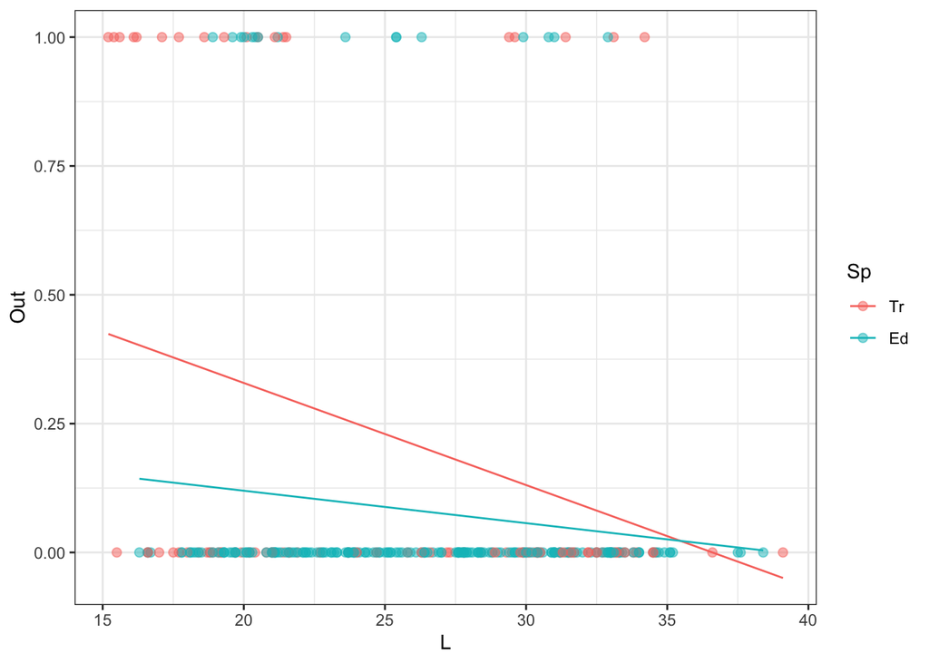

```r
mussels %>% ggplot(aes(L, Out, color = Sp)) +
  geom_point(size=2, alpha=.5) +
  geom_line(aes(y = fit0$fitted.values))
```

Но получается что-то странное…

Во-первых, непонятно, какая величина отложена на оси *y*. Во-вторых, предсказания модели выходят за границы допустимых значений (модель предсказывает отрицательные значения). Поэтому простая линейная модель нам не подходит. Надо искать что-то еще.

# Логистическая кривая

Собственно бинарные переменные неудобны для работы, поэтому надо найти способ превратить такую дискретную бинарную шкалу в «безграничную» и непрерывную. При моделировании нулей и единиц переходят к моделированию **вероятности получения единиц**.

Сама зависимая переменная в зависимости от предиктора распределена примерно так:

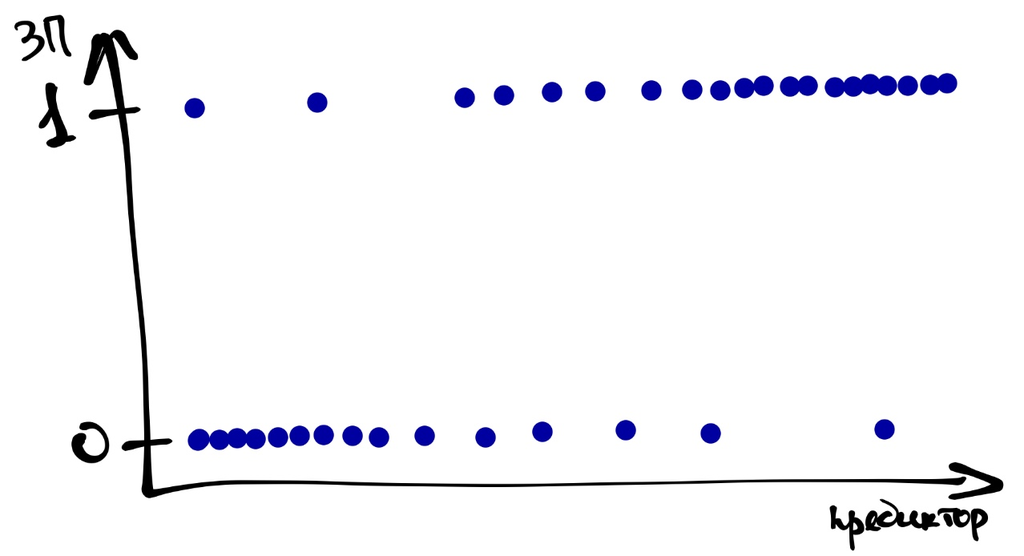

Введем новые обозначения:

- $p_i$ — вероятность события $y_i = 1$ при данных значениях предиктора,
- $1 - p_i$ — вероятность альтернативного события $y_i = 0$.

Получается непрерывная величина $0 \leq p_i \leq 1$.

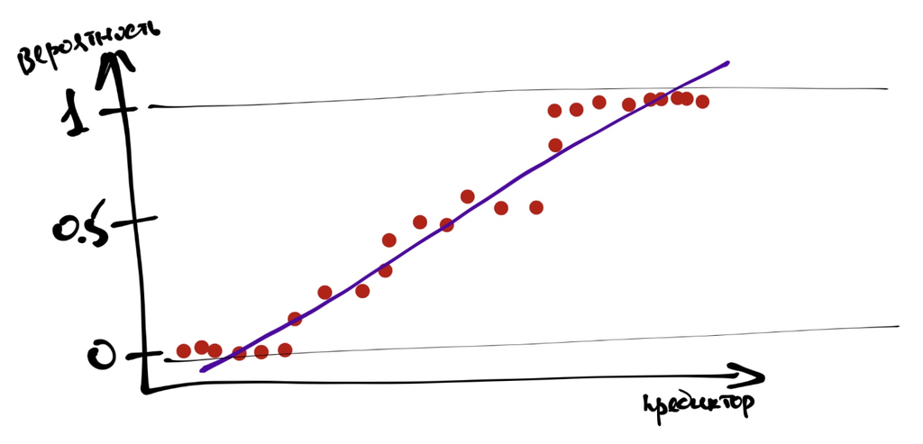

И вроде бы как ее можно уже моделировать. Но нужно помнить, что вероятность изменяется в пределах от нуля до единицы, а прямая ничем не ограничена. Поэтому прямая — не лучший вариант.

Такая закономерность моделируется логистической кривой.

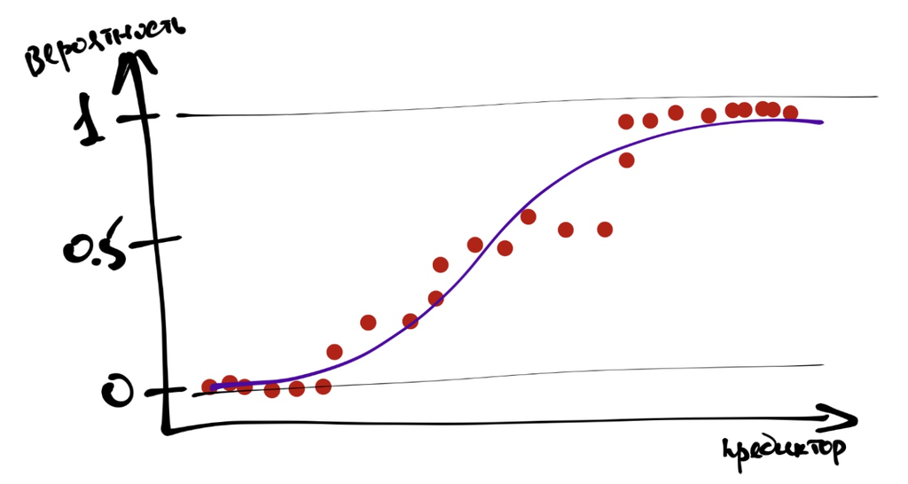

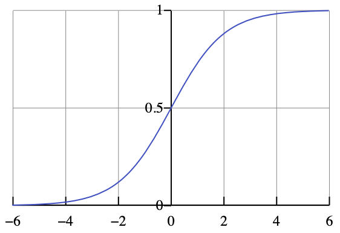

Она лежит как раз в пределах от 0 до 1. Наша логистическая кривая задается уравнением
$$p_i = \frac{e^{\beta_0 + \beta_1 x_i}}{1 + e^{\beta_0 + \beta_1 x_i}}$$

Логистическую кривую мы больше никогда не увидим [печаль :(], но она используется внутри функций, которыми мы строим модель.

# Шансы и логиты

Теперь нам надо побороться с ограниченностью логистической кривой. Для этого можно перейти от вероятностей к шансам.

**Шанс (отношение шансов, odds, odds ratio)** — это отношение вероятности успеха к вероятности неудачи. Их величина варьируется от $0$ до $+\infty$.

Уже лучше, но все еще не самый лучший вариант… Последний шаг, необходимый нам, чтобы все было хорошо, юзануть логарифм, который преобразуем шансы в логиты.

$$\mathrm{logit}(p) = \ln\left(\frac{p_i}{1-p_i}\right)$$

Значения логитов — трансформированные оценки вероятностей события. Они варьируют от $-\infty$ до $+\infty$, симметричны относительно нуля, и их удобно брать в качестве зависимой переменной для построения модели. Кроме того, logit-преобразование еще и линеаризует логистическую кривую. [Доказательство.](https://angelgardt.github.io/hseuxlab-andan/logit_transformation_proof.html)

Функция, используемая для линеаризации связи между предиктором и зависимой переменной, называется **связывающей функцией (linked function)**. Функция logit-преобразоввания — одна из нескольких связывающих функций, применяемых для анализа бинарных переменных отклика.

Итак, summary от всего, что было выше: 1. От дискретной оценки событий (0 и 1) переходим к оценке вероятностей. 2. Связь вероятностей с предиктором описывается логистической кривой. 3. Если при помощи функции связи перейти от вероятностей к логитам, то связь будет описываться прямой линией. 4. Параметры линейной модели для такой прямой можно оценить с помощью регрессионного анализа.

# Формулирование модели в математическом виде

**GLM с биномиальным распределением отклика**

$$y_i \thicksim \mathrm{Bin}(n = 1, p_i)
\\
\mathbb{E}(y_i) = p_i = \frac{e^{\beta_0 + \beta_1 x_1 + \dots + \beta_p x_p}}{1 + e^{\beta_0 + \beta_1 x_1 + \dots + \beta_p x_p}}$$

Функция связи (linked function):
$$\ln \left(\frac{p_i}{1 - p_i}\right) = \eta_i
\\
\eta_i = \beta_0 + \beta_1 x_{1i} + \dots + \beta_p x_{pi}$$

Для перехода от логитов к вероятностям используется функция, обратная функции связи. В данном случае, логистическое преобразование:
$$p_i = \frac{e^{\eta_i}}{1 + e^{\eta_i}}$$

# Подбор линейной модели

Для построения модели используется функция `glm()`. Синтаксически она очень похожа на `lm()`, но у неё есть дополнительный аргумент `family`, в который необходимо указать тип регрессии, которую мы собираемся использовать. Внутри указания типа можно указать функцию связи, с использвоание которой будет строиться модель.

```r
fit <- glm(Out ~ Sp*L, family = binomial(link = 'logit'), mussels)
summary(fit)
```

```
##
## Call:
## glm(formula = Out ~ Sp * L, family = binomial(link = "logit"),
##     data = mussels)
##
## Deviance Residuals:
##     Min       1Q   Median       3Q      Max
## -1.1053  -0.4917  -0.4066  -0.3128   2.5156
##
## Coefficients:
##             Estimate Std. Error z value Pr(>|z|)
## (Intercept)  1.82408    1.08147   1.687  0.09167 .
## SpEd        -1.98930    1.73332  -1.148  0.25110
## L           -0.12879    0.04601  -2.799  0.00513 **
## SpEd:L       0.03895    0.07146   0.545  0.58576
## ---
## Signif. codes:  0 '***' 0.001 '**' 0.01 '*' 0.05 '.' 0.1 ' ' 1
##
## (Dispersion parameter for binomial family taken to be 1)
##
##     Null deviance: 212.58  on 285  degrees of freedom
## Residual deviance: 190.94  on 282  degrees of freedom
## AIC: 198.94
##
## Number of Fisher Scoring iterations: 5
```

Модель сошлась, все ровно. Вызываем функцию `summary()`, чтобы посмотреть статистики модели. Вывод функции нам уже знаком, он аналогичен тому, с которым мы встречались, однако все-таки отличается некоторыми деталями.

Во-первых, нет F-статистики. Во-вторых, нет R². Это связано с тем, что алгоритм GLM не работает с дисперсией и суммой квадратов — модель подбирается **методом максимального правдоподобия**. Данный метод позволяет учесть разную форму распределений, которые мы можем моделировать с использованием GLM.

# Метод максимального правдоподобия

**Правдоподобие (likelihood)** — способ измерить соответствие имеющихся данных тому, что можно получить при определенных значениях параметров модели. Оно представляет собой произведение вероятностей получения каждой из точек данных:

$$L(\theta | \mathrm{data}) = \prod_{i=1}^n f(\mathrm{data}|\theta),$$
где $f(\mathrm{data}|\theta)$ — функция распределения с параметрами $\theta$.

Параметры модели должны максимизировать значения [логарифма] правдоподобия, т.е.
$$L(\theta | \mathrm{data}) \rightarrow \max$$
Однако для упрощения вычислений используют логарифмы правдоподобий (loglikelihood) и максимизируют их
$$\ln L(\theta | \mathrm{data}) \rightarrow \max$$
Аналитически такие задачи решаются редко, чаще используются методы численной оптимизации.

# Анализируем модель

Итак, продолжим изучать аутпут функции `summary()`. Обратимся к ней еще раз.

```r
summary(fit)
```

```
##
## Call:
## glm(formula = Out ~ Sp * L, family = binomial(link = "logit"),
##     data = mussels)
##
## Deviance Residuals:
##     Min       1Q   Median       3Q      Max
## -1.1053  -0.4917  -0.4066  -0.3128   2.5156
##
## Coefficients:
##             Estimate Std. Error z value Pr(>|z|)
## (Intercept)  1.82408    1.08147   1.687  0.09167 .
## SpEd        -1.98930    1.73332  -1.148  0.25110
## L           -0.12879    0.04601  -2.799  0.00513 **
## SpEd:L       0.03895    0.07146   0.545  0.58576
## ---
## Signif. codes:  0 '***' 0.001 '**' 0.01 '*' 0.05 '.' 0.1 ' ' 1
##
## (Dispersion parameter for binomial family taken to be 1)
##
##     Null deviance: 212.58  on 285  degrees of freedom
## Residual deviance: 190.94  on 282  degrees of freedom
## AIC: 198.94
##
## Number of Fisher Scoring iterations: 5
```

Мы видим знакомую нам табличку с оценками коэффициентов. В нашем случае есть intercept, которые содержит один из уровеней категориального предиктора (`SpTr`), второй уровень категориального предиктора (`SpEd`) и количественный предиктор на каждом из двух уровней (`L` и `SpEd:L`). У каждого предиктора есть информация о значении коэффициента при нем (`Estimate`), значение стандартной ошибки, z-value и p-value, рассчитанный для последнего.

Судя по аутпуту, значимым является предиктор длины только для вида-вселенца. Но так ли это?

Внимательно посмотрим на эту табличку. Раньше у нас были значения t-статистики — теперь z-теста. К чему это может приводить?

Чтобы ответить на этот вопрос, надо разобраться, что такое этот z-тест.

[figure not shown]

Значение z-value является результатом подсчета **теста Вальда** и позволяет оценить значимость коэффициента модели. Расчет статистики похож на подсчет t-теста, только распределение данной статистики *ассимптотически* стремиться к нормальному (отсюда и *z*). Ассимптотика приводит к тому, что опеределение значимости коэффициентов на маленьких выборках будет неточным.

$$H_0: \beta_k = 0 \\
H_1: \beta_k \neq 0 \\
\\
z = \frac{b_k - \beta_k}{SE_{b_k}} = \frac{b_k}{SE_{b_k}} \thicksim \mathcal{N}(0,\,1)$$

Поскольку значения теста Вальда нам не могут обеспечить достаточной точности оценки коэффициентов, нам необходимы другие метрики оценки значимости коэффициентов.

# Анализ девиансы и упрощение модели

Для получения более точных оценок необходимо поработать в логарифмами правдоподобий. Вообще логарифмы правдоподобий используются в GLM много для чего:

- для описания качества подгонки модели;
- для тестирования значимости подобранной модели в целом;
- для тестирования значимости отдельных предикторов;
- для отбора моделей.

Дла понимания механики анализа нам потребуется несколько полезных абстракций:

- **Насыщенная модель (saturated model)** — каждое уникальное наблюдение (сочетание предикторов) описывается одним из $n$ параметров.

$$\ln L_{\mathrm{sat}} = 0 \\
\mathrm{df}_{\mathrm{sat}} = n - p_{\mathrm{sat}} = n - n = 0$$

- **Нулевая модель (null model)** — все наблюдения описываются одним параметром (средним значением)

$$\hat y_i = \beta_0 \\
\ln L_{\mathrm{null}} \neq 0 \rightarrow -\infty \\
\mathrm{df}_{\mathrm{null}} = n - p_{\mathrm{null}} = n - 1$$

Наша **реальная (предложенная) модель**, которую мы подбираем, будет находится где-то между насыщенной и нулевой моделью (вернее, не сама модель, а значение логарифма её правдоподобия).

$$\hat y_i = \beta_0 + \beta_1 x_{1i} + \dots + \beta_p x_{pi} \\
\ln L_{\mathrm{model}} \neq 0 \\
\mathrm{df}_\mathrm{model} = n - p_\mathrm{model}$$

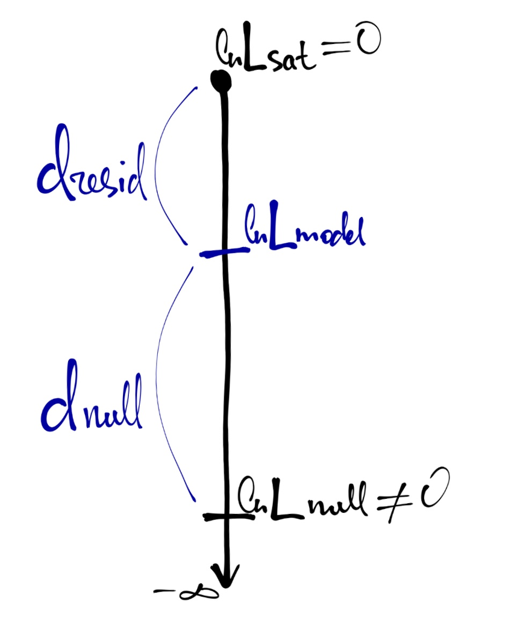

**Девианса** является мерой различия правдоподобий двух моделей (оценка разницы логарифмов правдоподобий). [см. рисунок выше]

**Остаточная девианса**
$$d_\mathrm{resid} = 2\big(\ln L_\mathrm{sat} - \ln L_\mathrm{model} \big) = -2 \ln(L_\mathrm{model})$$

**Нулевая девианса**
$$d_\mathrm{null} = 2 \big(\ln L_\mathrm{sat} - \ln L_\mathrm{null}\big) = -2 \ln(L_\mathrm{null})$$

Сравнение нулевой и остаточной девианс позволяет судить о статистической значимости модели в целом. Такое сравнение проводится с помощью **теста отношения правдоподобий (likelihood ratio test, LRT)**.

$$d_\mathrm{null} - d_\mathrm{resid} = -2 ( \ln L_\mathrm{null} - \ln L_\mathrm{model} ) = 2 (\ln L_\mathrm{model} - \ln L_\mathrm{null}) = 2 \ln \left( \frac{L_\mathrm{model}}{L_\mathrm{null}} \right) \\
\mathrm{LRT} = 2 \ln \left( \frac{L_\mathrm{M_1}}{L_\mathrm{M_2}} \right) = 2 (\ln L_\mathrm{M_1} - L_\mathrm{M_2}),$$
где $M_1,\, M_2$ — вложенные модели ($M_1$ — более полная, $M_2$ — уменьшенная), $L_\mathrm{M_1}, \, L_\mathrm{M_2}$ — правдоподобия.

Распределенеи разницы логарифмов правдоподобий аппроксиммируется распределением $\chi^2$ с числом степеней свободы $\mathrm{df} = \mathrm{df}_\mathrm{M_2} - \mathrm{df}_\mathrm{M_1}$.

LRT для тестирования значимости модели в целом:

$$\mathrm{LRT} = 2 \ln \left( \frac{L_\mathrm{model}}{L_\mathrm{null}} \right) = 2 (\ln L_\mathrm{model} - \ln L_{\mathrm{null}}) = d_\mathrm{null} - d_\mathrm{resid} \\
\mathrm{df} = p_\mathrm{model} - 1$$

LRT для тестирования значимости отдельных предикторов:

$$\mathrm{LRT} = 2 \ln \left( \frac{L_\mathrm{model}}{L_\mathrm{reduced}} \right) = 2 (\ln L_\mathrm{model} - \ln L_\mathrm{reduced}) \\
\mathrm{df} = p_\mathrm{model} - p_\mathrm{reduced}$$

Реализуем изученное в `R`.

Протестируем значимость модели в целом. Для этого неоходимо создать нулевую модель с одним предиктором — среднее — и передать эту модель и тестируемую в функцию `anova()` с указанием параметра `test = 'Chi'`. Получим нужным нам аутпут:

```r
fit_null <- glm(Out ~ 1, family = binomial(link = 'logit'), mussels)
anova(fit_null, fit, test = 'Chi')
```

```
## Analysis of Deviance Table
##
## Model 1: Out ~ 1
## Model 2: Out ~ Sp * L
##   Resid. Df Resid. Dev Df Deviance  Pr(>Chi)
## 1       285     212.58
## 2       282     190.94  3   21.631 7.783e-05 ***
## ---
## Signif. codes:  0 '***' 0.001 '**' 0.01 '*' 0.05 '.' 0.1 ' ' 1
```

Как можно увидеть, наша модель получилась статистически значима.

Для тестирования значимости отдельных предикторов можно (и лучше) использовать функцию `Anova()` из пакета `car`.

```r
Anova(fit)
```

```
## Analysis of Deviance Table (Type II tests)
##
## Response: Out
##      LR Chisq Df Pr(>Chisq)
## Sp     7.8938  1  0.0049604 **
## L     11.7480  1  0.0006091 ***
## Sp:L   0.2960  1  0.5863920
## ---
## Signif. codes:  0 '***' 0.001 '**' 0.01 '*' 0.05 '.' 0.1 ' ' 1
```

Мы получаем табличку, похожую на результат работы `summary()`, но с другими статистиками.

Аналогичный результат можно получить, используя базовую функцию `drop1()`, однако аутпут будет несколько отличаться. Данная функция тестирует значимость предикторов последовательно и позволяет постепенно упрощать модель.

```r
drop1(fit, test = 'Chi')
```

```
## Single term deletions
##
## Model:
## Out ~ Sp * L
##        Df Deviance    AIC     LRT Pr(>Chi)
## <none>      190.94 198.94
## Sp:L    1   191.24 197.24 0.29601   0.5864
```

Например, в нашем случае взаимодействие факторов оказалось статистически незначимым. Следовательно, его можно удалить из модели. Обновим имеющуюся модель в помощью функции `update()` и запишем в новый объект.

```r
fit1 <- update(fit, .~. -Sp:L)
drop1(fit1, test = 'Chi')
```

```
## Single term deletions
##
## Model:
## Out ~ Sp + L
##        Df Deviance    AIC     LRT  Pr(>Chi)
## <none>      191.24 197.24
## Sp      1   199.13 203.13  7.8938 0.0049604 **
## L       1   202.99 206.99 11.7480 0.0006091 ***
## ---
## Signif. codes:  0 '***' 0.001 '**' 0.01 '*' 0.05 '.' 0.1 ' ' 1
```

Повторное тестирование модели показывает, что оба оставшихся предиктора статистически значимы — больше модель упростить нельзя. Таким образом, мы получили нашу финальную модель.

На прошлом занятии мы упоминали **[информационный критерий Акаике](https://ru.wikipedia.org/wiki/%D0%98%D0%BD%D1%84%D0%BE%D1%80%D0%BC%D0%B0%D1%86%D0%B8%D0%BE%D0%BD%D0%BD%D1%8B%D0%B9_%D0%BA%D1%80%D0%B8%D1%82%D0%B5%D1%80%D0%B8%D0%B9_%D0%90%D0%BA%D0%B0%D0%B8%D0%BA%D0%B5) (Akaike information criterion)**, позволяющий сделать выбор из нескольких моделей. Его можно использовать и в нашем случае как дополнительную проверку.

```r
AIC(fit, fit1)
```

```
##      df      AIC
## fit   4 198.9443
## fit1  3 197.2404
```

С удалением взаимодействия из модели AIC снизился, что позволяет сделать вывод о том, что модель без взаимодействия лучше модели, включающей его.

# Интерпретация коэффициентов модели

Еще раз позовем summary модели:

```r
summary(fit1)
```

```
##
## Call:
## glm(formula = Out ~ Sp + L, family = binomial(link = "logit"),
##     data = mussels)
##
## Deviance Residuals:
##     Min       1Q   Median       3Q      Max
## -1.0583  -0.5099  -0.4096  -0.2894   2.5934
##
## Coefficients:
##             Estimate Std. Error z value Pr(>|z|)
## (Intercept)  1.46896    0.85072   1.727  0.08421 .
## SpEd        -1.06973    0.37879  -2.824  0.00474 **
## L           -0.11328    0.03497  -3.239  0.00120 **
## ---
## Signif. codes:  0 '***' 0.001 '**' 0.01 '*' 0.05 '.' 0.1 ' ' 1
##
## (Dispersion parameter for binomial family taken to be 1)
##
##     Null deviance: 212.58  on 285  degrees of freedom
## Residual deviance: 191.24  on 283  degrees of freedom
## AIC: 197.24
##
## Number of Fisher Scoring iterations: 5
```

Что значат эти непонятные коэффициенты при предикторах? В общих линейных моделях все ясно как белый день, а тут какая-то дичь…

Посмотрим на математическую запись нашей модели:

$$\mathrm{Out}_i \thicksim \mathrm{Bin}(n = 1, \, p_i) \\
\mathbb{E}(\mathrm{Out}_i) = p_i \\
\ln \left(\frac{p_i}{1 - p_i}\right) = \eta_i \\
\eta_i = 1.469 - 1.070 \, \mathrm{Sp}_{\mathrm{Ed} \, i} - 0.113 \, \mathrm L_{i}$$

Наша зависимая переменная — логарифм отношения шансов. От этого и будем толкаться.

Тогда,

- $b_0$, интерсепт, показывает *логарифм отношения шансов для базового уровня* (`Tr`) дискретного предиктора (`Sp`);
- $b_1$ показывает, *на сколько единиц изменяется логарифм отношения шансов* для данного уровня (`Ed`) дискретного предиктора (`Sp`) по сравнению с базовым уровнем (`Tr`);
- $b_2$ показывает, *на сколько единиц изменится логарифм отношения шансов* при изменении значения предиктора (`L`) на единицу.

Корректно, но непонятно… Чтобы разобраться лучше, немного потупим в алгебру.

### Немного алгебры для понимания сути коэффициентов

Пусть у нас есть модель с одним непрервным предиктором. Тогда она будет записываться так:

$$\eta = b_0 + b_1 x$$

В терминах логитов её можно записать следующим образом:

$$\eta = \ln \left( \frac{p}{1 - p} \right) = \ln (\mathrm{odds})$$

Как изменится предсказание модели при изменении предиктора на единицу?

$$\eta_{x+1} - \eta_x = \ln (\mathrm{odds}_{x+1}) - \ln (\mathrm{odds}_{x}) =
\ln \left( \frac{\mathrm{odds}_{x+1}}{\mathrm{odds}_x} \right)$$
$$\eta_{x+1} - \eta_x = b_0 + b_1 (x + 1) - b_0 - b_1x = b_1$$
$$\ln \left( \frac{\mathrm{odds}_{x+1}}{\mathrm{odds}_{x}} \right) = b_1$$
$$\frac{\mathrm{odds}_{x+1}}{\mathrm{odds}_{x}} = e^{b_1}$$

Таким образом, $e^{b_1}$ показывает, во сколько раз изменится отношение шансов при увеличении предиктора на единицу. Для дискретных предикторов $e^{b_1}$ покажет, во сколько раз различается отношение шансов для данного уровня предиктора по сравнению с базовым.

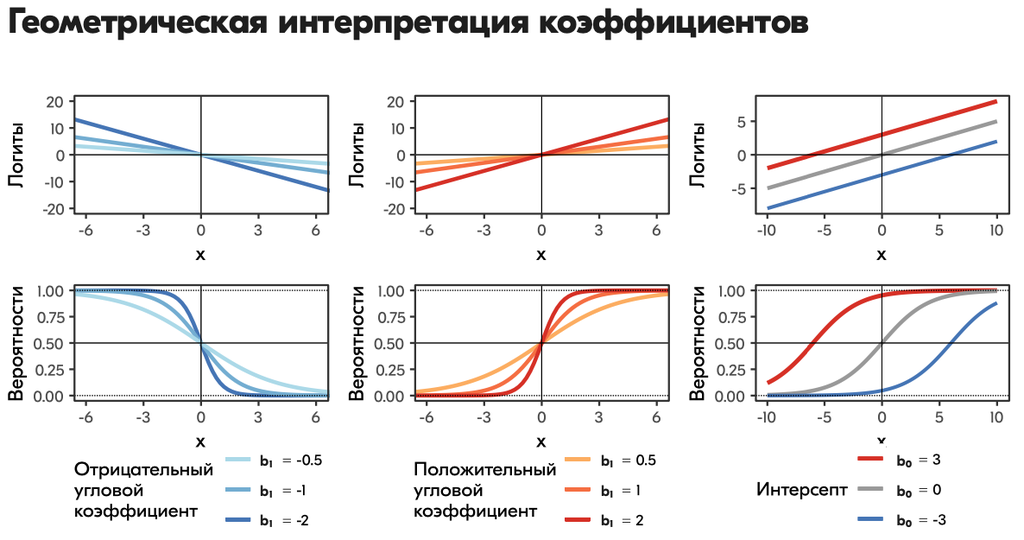

Теперь мы можем тракровать полученные коэффициенты нормальным языком.

$$\eta_i = 1.469 - 1.070 \, \mathrm{Sp}_{\mathrm{Ed} \, i} - 0.113 \, \mathrm L_{i}$$

Отношение шансов быть съеденной у мидии, относящейся к группе `Ed` дискретного фактора `Sp`, отличается в $e^{-1.07} = 0.343$ раза от аналогичной характеристики мидии, относящейся к базовому уровню (`Tr`). То есть вероятность выжить у мидии из группы `Ed` больше, чем у мидии из группы `Tr`.

# Предсказательная сила модели

Проверим, насколько эффективна наша модель для предсказаний. Воспользуется функцией `predict()` и создадим новую колонку с предсказанными вероятностями.

```r
mussels %>% mutate(predicted = predict(fit1, type = 'response')) -> mussels
```

```r
mussels %>% mutate(out_pred = ifelse(mussels$predicted > .6, 'eaten_p', 'not_eaten_p')) -> mussels
```

Теперь построим **confusion matrix** и посмотрим на качество предсказаний:

```r
table(mussels$Outcome, mussels$out_pred)
```

```
##
##             not_eaten_p
##   eaten              35
##   not_eaten         251
```

Качество предсказаний у нас мягко говоря нутакое. Модель предсказывает в прицнипе очень маленькую вероятность того, что мидию съедят. То есть несмотря на то, что для научных целей изучения и анализа закономерностей она хороша, для каких-либо предсказаний она не годится.